# 머신러닝을 위한 선형대수학 행렬

## [3] 행렬의 내적곱 (np.dot)

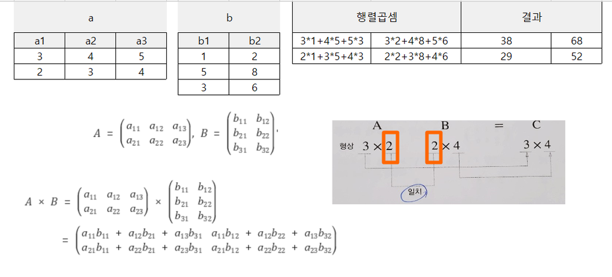

```python
import numpy as np

a=[[3,4,5],
   [2,3,4]]
a=np.array(a)
   # 2행3열

b=[[1,2],[5,8],[3,6]]
b=np.array(b)
print(a.shape, b.shape)
np.dot(a,b)   # 행렬의 내적곱
```

```
(2, 3) (3, 2)
```

```
array([[38, 68],
       [29, 52]])
```

#### 참고: wx+b 계산식에 내적곱이 사용됨

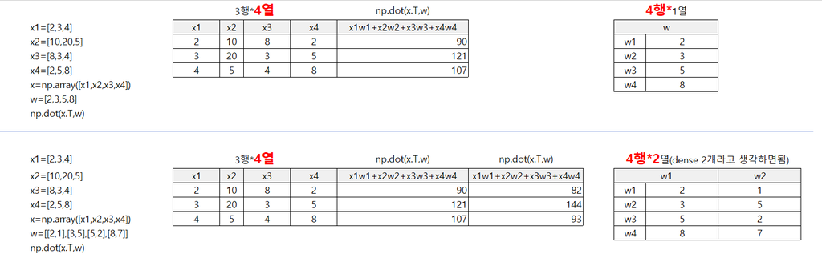

## [4] 직교행렬(Orthogonal matrix)

```
- 선형대수학에서, 직교 행렬(直交行列, orthogonal matrix)은 행벡터와 열벡터가 유클리드 공간의 정규 직교 기저를 이루는 실수 행렬
- 직교 행렬의 정의는 모든 column들이 orthonormal set을 이루는 행렬이다.
    - orthonormal set은 orthogonal + normal의 합성어임.
    - orthogonal, 즉 모든 column 벡터들이 서로 직교한다는 뜻으로 수식적으로는 내적 (inner product)이 0을 뜻함.
    - 즉 normal, 모든 벡터의 크기가 1로 맞춰져 있다는 것임(참고: 벡터의 크기는 자기 자신과 내적한 뒤, 제곱근으로 구함)
```

### [4-1] 선형독립과 선형종속

<출처> 더북 '모두의 인공지능 기초 수학'

https://thebook.io/080246/part03/ch10/unit19/02/

- 머신러닝에서 데이터셋 특성(x변수 갯수)이 많아지면 오버피팅(overfitting)이 발생함.
- 이러한 현상을 차원의 저주라고 하는데, 이를 해결하는 방법 중 하나로 PCA(Principal Component Analysis)가 있음
- PCA는 특성 추출(feature extraction) 방법을 이용하는데, 특성 추출은 원본 특성의 조합으로 새로운 특성을 생성하는 것임
- 즉, 데이터에서 주축을 찾고 모든 데이터를 해당 축에 투영시켜서(원본 특성들의 선형 결합으로) 새로운 특성을 만듦
- 이때 데이터의 특성 간 관계가 선형 종속 관계일 때 특성 추출이 잘 작동함.
- 해가 유일무이한 경우는 주어진 벡터가 선형 독립일 때 / 벡터가 선형 종속이면 해가 무수히 많음(평행사변형을 여러개그릴수있음)

### [역행렬을 이용한 종속여부 확인]

- 행렬식이 '0'이 아니면 역행렬이 존재==> 선형독립
- 행렬식이 '0'이면 역행렬이 존재하지 않음 ==> 선형종속
- https://skyjwoo.tistory.com/46

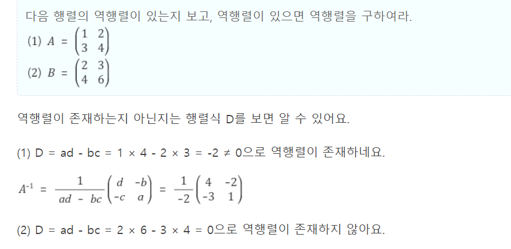

https://mathbang.net/567

```python
## 역행렬이 존재하지 않는 선형종속
v1=[4,2]
v2=[8,4]
V=np.array([v1,v2])

import numpy.linalg
print(V)
print(numpy.linalg.det(V)) #  print(4*4-2*8)      # 선형종속,   # 0으로 역행렬이 존재하지 않음.
print('rank % d' % np.linalg.matrix_rank(V)) # 랭크계산, 1이면 선형종속 # https://thebook.io/080246/part03/ch10/unit19/03-18/


print('-'*100)
## 역행렬이 존재하지 않음으로 단위행렬이 존재하지 않음.
B=np.array([v1,v2])
c=np.array([0,0]).reshape(-1,1); c
Bc=np.hstack([B, c]);Bc
sp.Matrix(Bc).rref()
```

```
[[4 2]
 [8 4]]
0.0
rank  1
----------------------------------------------------------------------------------------------------
```

```
(Matrix([
 [1, 1/2, 0],
 [0,   0, 0]]),
 (0,))
```

```python
## 역행렬이 존재하는 선형독립
v1=[3,0]
v2=[0,-2]
V=np.array([v1,v2])
print(V)
print(numpy.linalg.det(V))  # print(3*-2-0*0)   # 0이 아님으로 역행렬 존재
print('rank % d' % np.linalg.matrix_rank(V)) # 랭크계산, 2이상이면 선형독립 # https://thebook.io/080246/part03/ch10/unit19/03-18/

print('-'*100)
## 역행렬이 존재함으로 단위행렬이 생성됨
B=np.array([v1,v2])
c=np.array([0,0]).reshape(-1,1); c
Bc=np.hstack([B, c]);Bc
sp.Matrix(Bc).rref()
```

```
[[ 3  0]
 [ 0 -2]]
-6.0
rank  2
----------------------------------------------------------------------------------------------------
```

```
(Matrix([
 [1, 0, 0],
 [0, 1, 0]]),
 (0, 1))
```

### [4-2] 단위벡터

[output not shown]

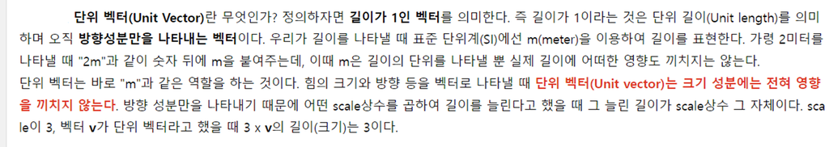

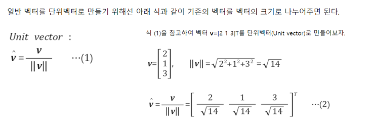

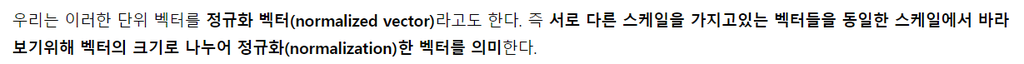

```python
v=[1,-2,3]
print(np.linalg.norm(v,1))  # 1+2+3
print(np.linalg.norm(v,2))   # (1+4+9)**0.5
```

```
6.0
3.7416573867739413
```

```python
import numpy as np

v = np.random.rand(10)
print(v)
print('*'*100)

print('\n▶단위벡터를 출력합니다.\n')
normalized_v = v / np.sqrt(np.sum(v**2))
print(normalized_v)

print('-'*100)

normalized_v = v/np.linalg.norm(v)
print(normalized_v)

print('-'*100)

from sklearn.preprocessing import normalize
normalized_v = normalize(v[:,np.newaxis], axis=0).ravel()
print(normalized_v)

print('-'*100)
from scipy import linalg
v / linalg.norm(v)


# 참고: https://jimmy-ai.tistory.com/81
```

```
[0.75599333 0.37785357 0.64691619 0.72463736 0.16955933 0.91391956
 0.96976773 0.02858146 0.41910068 0.64166548]

▶단위벡터를 출력합니다.

[0.37563084 0.18774432 0.32143362 0.36005099 0.08424904 0.45409974
 0.48184906 0.01420129 0.2082388  0.3188247 ]
----------------------------------------------------------------------------------------------------
[0.37563084 0.18774432 0.32143362 0.36005099 0.08424904 0.45409974
 0.48184906 0.01420129 0.2082388  0.3188247 ]
----------------------------------------------------------------------------------------------------
[0.37563084 0.18774432 0.32143362 0.36005099 0.08424904 0.45409974
 0.48184906 0.01420129 0.2082388  0.3188247 ]
----------------------------------------------------------------------------------------------------
```

```
array([0.37563084, 0.18774432, 0.32143362, 0.36005099, 0.08424904,
       0.45409974, 0.48184906, 0.01420129, 0.2082388 , 0.3188247 ])
```

### [4-3] 직교벡터

- 두 벡터 사이의 각도가 90도를 이루는 것을 직교 벡터(orthogonal vector)라고 함
- https://thebook.io/080246/part03/ch10/unit20/03/

||a||2 + ||b||2 = ||a + b||2

```python
### 아래 두 자료는 직교 행렬임
# https://thebook.io/080246/part03/ch10/unit20/03-03/
def orthogonal(v1,v2):
    return (np.sum(v1**2+v2**2))**0.5 == (np.sum((v1+v2)**2))**0.5

a=np.array([0,-1,0])
b=np.array([1,0,0])
c=np.array([0,0,1])
d=np.array([0,1,1])

print(orthogonal(a,b),orthogonal(a,c),orthogonal(b,c),orthogonal(c,d))
print(np.dot(a,b),np.dot(a,c),np.dot(b,c),np.dot(c,d))


##
# np.sum(x.T*x+y.T*y)==np.sum((x+y).T*(x+y))
# np.dot(x.T,x)+np.dot(y.T,y) == np.dot((x+y).T, (x+y))
```

```
True True True False
0 0 0 1
```

```python
# 코사인각도값을 이용하여서 직교행렬 여부 확인하기
# 코사인각도값이 0 이나오면 직교행렬임 (두 벡터가 이루는 각이 작을수록 유사도가 높고, 각이 클수록 유사도가 낮습니다.)
from numpy.linalg import norm
def cos_sim(A, B):
    return np.dot(A, B)/(norm(A)*norm(B))     # norm 옵션없으면 기본값 norm2임 (제곱값의합**0.5)
cos_sim(a,b),cos_sim(a,c),cos_sim(b,c),cos_sim(c,d)
```

```
(0.0, 0.0, 0.0, 0.7071067811865475)
```

```python
v=[1,-2,3]
norm(v,2)
```

```
3.7416573867739413
```

```python
x=np.array([2,1,3])
y=np.array([3,3,-3])
orthogonal(x,y)
```

```
True
```

## [5] 차원축소법

- 상관계수가 높은 변수중 일부 변수 제거
- PCA(Principal component를 활용): 차원을 줄이면서 정보의 손실을 최소화함
- 변수선택법
- penalty 기반 regression
- convolutional neural network
- drop out & bagging

### [5-1]구글검색해서 정리

- 피쳐 선택(Feature Selection)
- 피쳐 추출 (Feature Extraction)

### [5-2] 고유벡터

구글링 '고유벡터' 또는 여기 사이트 자료 정리하세요.  
https://suhwanc.tistory.com/96  
https://thebook.io/080246/part02/ch12/unit25/

- 고유벡터는 역행렬이 존재하지 않을때, 행렬식(a*d-b*c)이 0일때, 존재

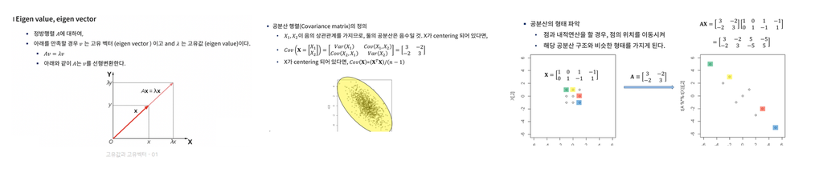

https://rfriend.tistory.com/182

- 고유값 구하기, 고유값의합은 분산의 합과 같음

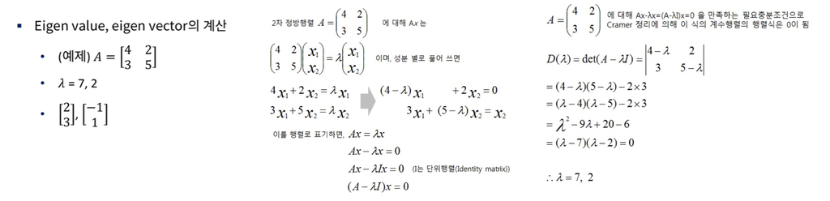

- 고유벡터 [2,3], [-1,1] 값 구하는 공식은 위의 링크에서
- 더북의 'https://thebook.io/080246/part02/ch12/unit25-07/' 에서 확인
- svd 특이값분해(Singular Value Decomposition, SVD) 가 속도가 빠름. -> PCA를 진행하기도 함.

```python
### 고유벡터 사용처
# https://cnp-0717.tistory.com/5
```

### [5-3] 주성분분석(Principal Component Analysis)

- 공분산 행렬에서 고유 벡터/고유값을 구하고
- 가장 분산이 큰 방향을 가진 고유벡터(e1) 에 입력데이터를 선형변환
- 고유벡터(e1) 과 직교하며, e1 다음으로 분산이 큰 e2 고유벡터에 또 선형변환.
- 1에서 행렬 A의 공분산 행렬의 고유벡터가 데이터가 최대한 안 겹치게, 멀리 퍼지게 하는 길이가 긴 축의 벡터가 된다.
- 2에서 고유값이 가장 큰 것에 매핑되는 고유 벡터(e1)가 1의 고유 벡터 중 데이터의 분산이 가장 큰(데이터가 최대한 안 겹치게, 멀리 - - 퍼지게 하는 길이가 긴) 축의 벡터가 된다.
- 3에서 2의 벡터와 직교하며 다음으로 고유값이 큰(다음으로 분산이 큰) 벡터(e2)를 찾는다

https://velog.io/@lighthouse97/PCAPrincipal-Component-Analysis

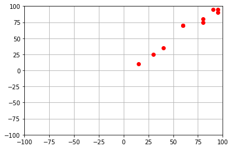

```python
### https://blog.naver.com/pjt3591oo/222636875246   의 1/2 지점정도 부터
import matplotlib.pyplot as plt

korean = [95, 90, 80, 60, 40, 80, 95, 30, 15, 60]
english = [95, 95, 75, 70, 35, 80, 90, 25, 10, 70]

plt.plot(korean, english, 'ro')
plt.axis([-100, 100, -100, 100]) # x축, y축 범위
plt.grid()
plt.show()
```

```
국어성적 z-score [ 1.1  0.9  0.6 -0.2 -0.9  0.6  1.1 -1.3 -1.8 -0.2]
영어성적 z-score [ 1.1  1.1  0.4  0.2 -1.   0.5  0.9 -1.4 -1.9  0.2]
```

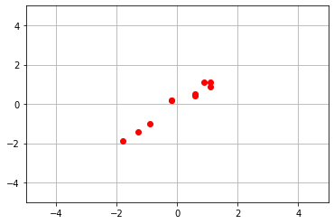

```python
# 해당 데이터를 그대로 진행하면 너무 분산이 너무 커지기 때문에 데이터 표준화를 진행합니다.
# 표준화는 평균 0, 분산 1이 되도록 데이터 스케일을 제거하는 행위를 의미합니다.

import numpy as np
import math
import matplotlib.pyplot as plt

def scale_less(data):
  return np.round((data - np.mean(data, axis=0)) / np.std(data, axis=0), 1)

korean = scale_less([95, 90, 80, 60, 40, 80, 95, 30, 15, 60])
english = scale_less([95, 95, 75, 70, 35, 80, 90, 25, 10, 70])

print('국어성적 z-score', korean)
print('영어성적 z-score', english)

plt.plot(korean, english, 'ro')
plt.axis([-5, 5, -5, 5])
plt.grid()
plt.show()
```

```python
import numpy as np
import math
import matplotlib.pyplot as plt

def covariance_matrix(data1, data2):
  korean = data1
  english = data2

  korean_average = sum(korean)/len(korean)
  english_avergrage = sum(english)/len(english)

  korean_deviation = [a - korean_average for a in korean] # 편차
  english_deviation = [a - english_avergrage for a in english] # 편차

  korean_variance = [(a - korean_average) ** 2 for a in korean] # 분산 - 표준편차 1 - 음수를 없애기 위해 편차 제곱
  english_variance = [(a - english_avergrage) ** 2 for a in english] # 분산 - 표준편차 1 - 음수를 없애기 위해 편차 제곱

  korean_variance = sum(korean_variance)/len(korean_variance) # 분산 - 표준편차 2 - 평균을 구하여 분산을 구한다
  english_variance = sum(english_variance)/len(english_variance) # 분산 - 표준편차 2 - 평균을 구하여 분산을 구한다

  korean_std_deviation = math.sqrt(float(korean_variance)) # 표준편차 3 - 제곱을 했기 떄문에 제곱근을 하여 표준편차를 구한다
  english_str_deviation = math.sqrt(float(english_variance)) # 표준편차 3 - 제곱을 했기 떄문에 제곱근을 하여 표준편차를 구한다

  data_len = len(korean_deviation) if len(korean_deviation) < len(english_deviation) else len(english_deviation)

  cov = [korean_deviation[idx] * english_deviation[idx] for idx in range(0, data_len)]
  cov = sum(cov) / len(cov)
  relation = cov / (korean_std_deviation * english_str_deviation)

  print('국어성적 분산: %s'%(np.round(korean_variance, 2)))
  print('영어성적 분산: %s'%(np.round(english_variance, 2)))

  print('국어성적 표준편차: %s'%(math.sqrt(np.round(korean_std_deviation, 2))))
  print('영어성적 표준편차: %s'%(math.sqrt(np.round(english_str_deviation, 2))))

  print('공분산: %s'%(np.round(cov, 2)))
  print('상관계수: %s'%(relation))
  return [
    [np.round(korean_variance, 2), np.round(cov, 2)], # 분산, 공분산
    [np.round(cov, 2), np.round(english_variance, 2)] # 공분산, 분산
  ]

def scale_less(data):
  return np.round((data - np.mean(data, axis=0)) / np.std(data, axis=0), 1)

korean = scale_less([95, 90, 80, 60, 40, 80, 95, 30, 15, 60])
english = scale_less([95, 95, 75, 70, 35, 80, 90, 25, 10, 70])

print('국어성적 z-score', korean)
print('영어성적 z-score', english)

# plt.plot(korean, english, 'ro')
# plt.axis([-5, 5, -5, 5])
# plt.grid()
# plt.show()

cov_mat = covariance_matrix(korean, english)
print('공분산 행렬:', cov_mat)
```

```
국어성적 z-score [ 1.1  0.9  0.6 -0.2 -0.9  0.6  1.1 -1.3 -1.8 -0.2]
영어성적 z-score [ 1.1  1.1  0.4  0.2 -1.   0.5  0.9 -1.4 -1.9  0.2]
국어성적 분산: 0.98
영어성적 분산: 1.03
국어성적 표준편차: 0.99498743710662
영어성적 표준편차: 1.004987562112089
공분산: 0.98
상관계수: 0.9765970591632542
공분산 행렬: [[0.98, 0.98], [0.98, 1.03]]
```

```python
#고유값, 고유벡터 구하기

mat = np.array(cov_mat)

w, v = np.linalg.eig(mat)
print('고유값', np.round(w, 2))
print('고유벡터', np.round(v, 2))
```

```
고유값 [0.02 1.99]
고유벡터 [[-0.72 -0.7 ]
 [ 0.7  -0.72]]
```

```
고유값 [0.02 1.99]
고유백터 [[-0.72 -0.7 ]
 [ 0.7  -0.72]]
```

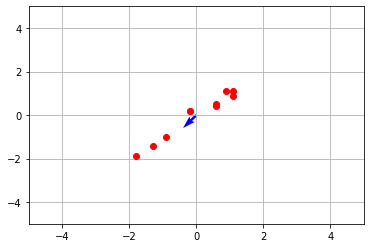

```python
#데이터에 고유벡터 적용해보기

mat = np.array(cov_mat)

w, v = np.linalg.eig(mat)
print('고유값', np.round(w, 2))
print('고유백터', np.round(v, 2))

plt.plot(korean, english, 'ro')
plt.axis([-5, 5, -5, 5])

plt.quiver(0, 0, v[0][0], v[0][1], color = 'blue')
plt.grid()
plt.show()

# 고유값은 분산의 합과 같음 0.98+1.03, 0.02+ 1.99
```

[output not shown]

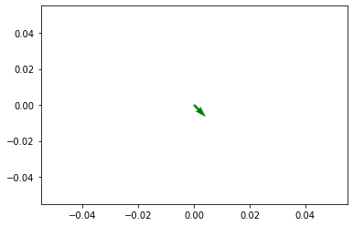

```python
plt.quiver(0, 0, v[1][0], v[1][1], color = 'green')
```

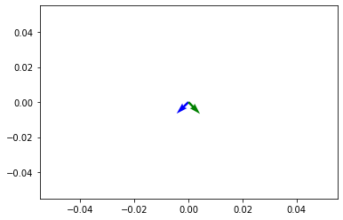

```python
plt.quiver(0, 0, v[0][0], v[0][1], color = 'blue') # 고유값: 1.99
plt.quiver(0, 0, v[1][0], v[1][1], color = 'green') # 고유값: 0.02
```

- https://excelsior-cjh.tistory.com/167
- https://ko.khanacademy.org/math/linear-algebra/vectors-and-spaces/linear-independence/v/linear-algebra-introduction-to-linear-independence?modal=1